# bellabeat_case_Study

##Business Task

##Discover useful patterns in the data to learn how users are using fitness technology.

##Limitations of the data

##1. No data on gender for a study specifically for women’s products. Some women may be held back by biological factors such as menstrual cycles and pregnancy as compared to men’s phusical output.

##2.No data on age. Age is known to affect maximum heart rate capable for a human being.

##3. Data is from 2016 so it may be outdated. Popularity in wearable fitness technology soaredin years following with Apple Watch as a big example.

##Product - Fitness Watch

##This wellness watch combines the timeless look of a classic timepiece with smart technology to track user activity, sleep, and stress. The Time watch connects to the Bellabeat app to provide you with insights into your daily wellness.

##Stage 1 - Ask

##1. What observations can be made about user activity? ##2. How could these observations apply to bellabeat’s product? ##3.What should the recommendaed focus points be moving forward?

##Stage 2 - Prepare and Process

##Preparing the data

```r
activity <- read.csv("Desktop/Fitbit/dailyActivity_merged.csv")
dailysteps <- read.csv("Desktop/Fitbit/dailySteps_merged.csv")
dailycals <- read.csv("Desktop/Fitbit/dailyCalories_merged.csv")
hourlycals <- read.csv("Desktop/Fitbit/hourlyCalories_merged.csv")
weight <- read.csv("Desktop/Fitbit/weightLogInfo_merged.csv")
sleep <- read.csv("Desktop/Fitbit/sleepDay_merged.csv")
```

##Seeing whats in the data.

```r
colnames(dailysteps)
```

```
[1] "Id"          "ActivityDay" "StepTotal"
```

```r
colnames(dailycals)
```

```
[1] "Id"          "ActivityDay" "Calories"
```

```r
colnames(hourlycals)
```

```
[1] "Id"           "ActivityHour" "Calories"
```

```r
colnames(weight)
```

```
[1] "Id"             "Date"           "WeightKg"
[4] "WeightPounds"   "Fat"            "BMI"
[7] "IsManualReport" "LogId"
```

```r
colnames(activity)
```

```
 [1] "Id"                       "ActivityDate"
 [3] "TotalSteps"               "TotalDistance"
 [5] "TrackerDistance"          "LoggedActivitiesDistance"
 [7] "VeryActiveDistance"       "ModeratelyActiveDistance"
 [9] "LightActiveDistance"      "SedentaryActiveDistance"
[11] "VeryActiveMinutes"        "FairlyActiveMinutes"
[13] "LightlyActiveMinutes"     "SedentaryMinutes"
[15] "Calories"
```

##Structure of largest data set

```r
str(activity)
```

```
'data.frame':   940 obs. of  15 variables:
 $ Id                      : num  1.5e+09 1.5e+09 1.5e+09 1.5e+09 1.5e+09 ...
 $ ActivityDate            : chr  "4/12/2016" "4/13/2016" "4/14/2016" "4/15/2016" ...
 $ TotalSteps              : int  13162 10735 10460 9762 12669 9705 13019 15506 10544 9819 ...
 $ TotalDistance           : num  8.5 6.97 6.74 6.28 8.16 ...
 $ TrackerDistance         : num  8.5 6.97 6.74 6.28 8.16 ...
 $ LoggedActivitiesDistance: num  0 0 0 0 0 0 0 0 0 0 ...
 $ VeryActiveDistance      : num  1.88 1.57 2.44 2.14 2.71 ...
 $ ModeratelyActiveDistance: num  0.55 0.69 0.4 1.26 0.41 ...
 $ LightActiveDistance     : num  6.06 4.71 3.91 2.83 5.04 ...
 $ SedentaryActiveDistance : num  0 0 0 0 0 0 0 0 0 0 ...
 $ VeryActiveMinutes       : int  25 21 30 29 36 38 42 50 28 19 ...
 $ FairlyActiveMinutes     : int  13 19 11 34 10 20 16 31 12 8 ...
 $ LightlyActiveMinutes    : int  328 217 181 209 221 164 233 264 205 211 ...
 $ SedentaryMinutes        : int  728 776 1218 726 773 539 1149 775 818 838 ...
 $ Calories                : int  1985 1797 1776 1745 1863 1728 1921 2035 1786 1775 ...
```

```r
head(activity)
```

|  | Id | ActivityDate | TotalSteps | TotalDistance | TrackerDistance | LoggedActivitiesDistance | VeryActiveDistance | ModeratelyActiveDistance | LightActiveDistance | SedentaryActiveDistance | VeryActiveMinutes | FairlyActiveMinutes | LightlyActiveMinutes | SedentaryMinutes | Calories |
| --- | --- | --- | --- | --- | --- | --- | --- | --- | --- | --- | --- | --- | --- | --- | --- |
| 1 | 1503960366 | 4/12/2016 | 13162 | 8.50 | 8.50 | 0 | 1.88 | 0.55 | 6.06 | 0 | 25 | 13 | 328 | 728 | 1985 |
| 2 | 1503960366 | 4/13/2016 | 10735 | 6.97 | 6.97 | 0 | 1.57 | 0.69 | 4.71 | 0 | 21 | 19 | 217 | 776 | 1797 |
| 3 | 1503960366 | 4/14/2016 | 10460 | 6.74 | 6.74 | 0 | 2.44 | 0.40 | 3.91 | 0 | 30 | 11 | 181 | 1218 | 1776 |
| 4 | 1503960366 | 4/15/2016 | 9762 | 6.28 | 6.28 | 0 | 2.14 | 1.26 | 2.83 | 0 | 29 | 34 | 209 | 726 | 1745 |
| 5 | 1503960366 | 4/16/2016 | 12669 | 8.16 | 8.16 | 0 | 2.71 | 0.41 | 5.04 | 0 | 36 | 10 | 221 | 773 | 1863 |
| 6 | 1503960366 | 4/17/2016 | 9705 | 6.48 | 6.48 | 0 | 3.19 | 0.78 | 2.51 | 0 | 38 | 20 | 164 | 539 | 1728 |

##Checking for Null values in each dataframe I will use.

```r
is.null(activity)
```

```
[1] FALSE
```

```r
is.null(weight)
```

```
[1] FALSE
```

```r
is.null(sleep)
```

```
[1] FALSE
```

##Merging Dataframes

##I will merge the activity data along with the sleep and weight data to find correlation there based in the fact that they are three of the largest factors that lead to a healthy lifestyle.

```r
activeweight <- merge(activity, weight, by=c('Id'))
```

```r
activesleep <- merge(activity, sleep, by=c('Id'))
```

**Stage 3 - Analysis**

##Analysis

##The longer the distance the more calories burned. This also shows users are using there products because a positive relationship is shown between longer distances and calories burned.

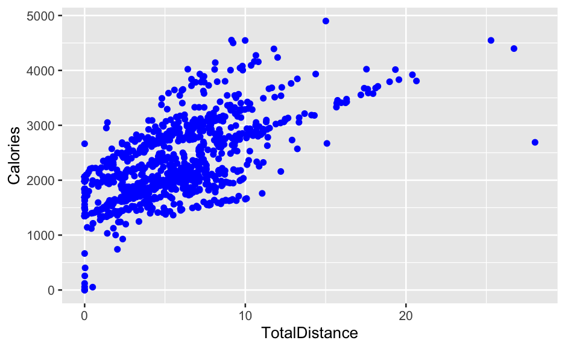

```r
ggplot(data = activity) + geom_point(mapping = aes(x = TotalDistance  , y = Calories) , color = 'blue')
```

##Highly Active users burned the most calories in less minutes. Light Active users burned calories for the most prolonged period of time.

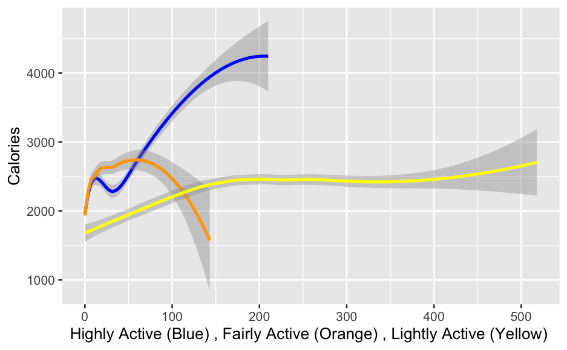

```r
ggplot(data = activity) + geom_smooth(mapping = aes(x = VeryActiveMinutes  , y = Calories ) , color = 'blue') +  geom_smooth(mapping = aes(x = FairlyActiveMinutes  , y = Calories ) , color = 'Orange') + geom_smooth(mapping = aes(x = LightlyActiveMinutes  , y = Calories ) , color = 'yellow') + labs(x = "Highly Active (Blue) , Fairly Active (Orange) , Lightly Active (Yellow) ", y = "Calories")
```

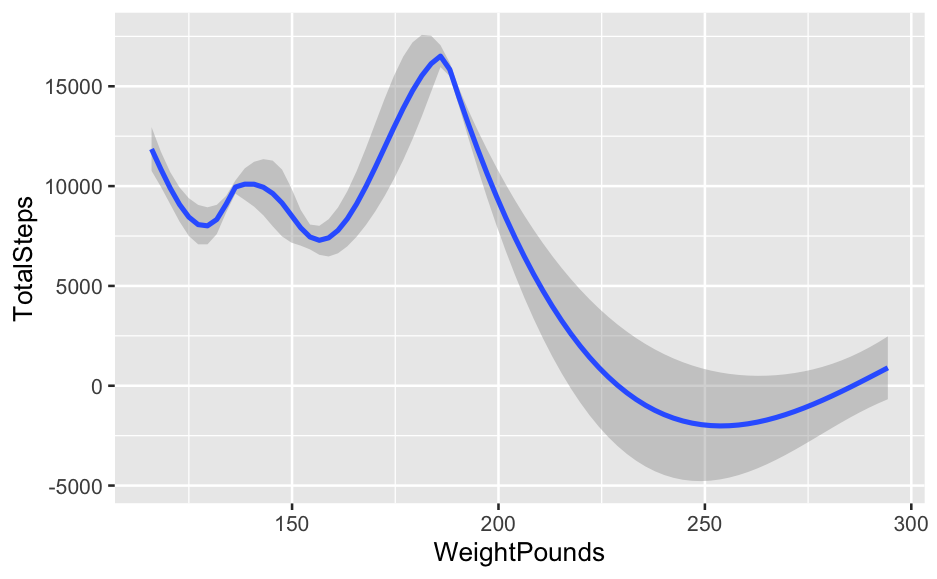

```r
ggplot(data = activeweight) + geom_smooth(mapping = aes(x = WeightPounds, y = TotalSteps ))
```

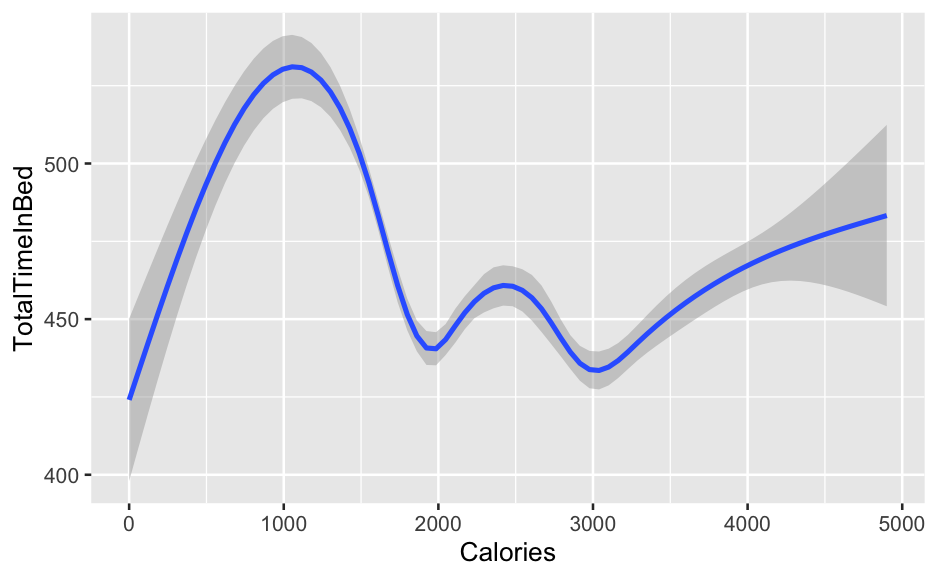

```r
ggplot(data = activesleep) + geom_smooth(mapping = aes (x = Calories, y = TotalTimeInBed))
```

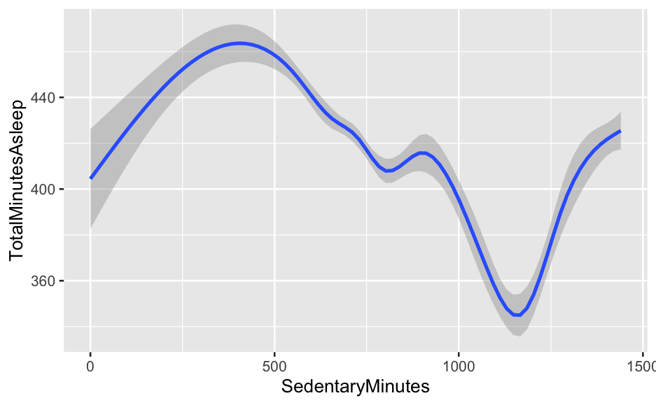

```r
ggplot(data = activesleep)+ geom_smooth(mapping = aes(x= SedentaryMinutes, y = TotalMinutesAsleep ))
```

##Summary

##1.There is a positive relationship between activity and calories burned in the user data meaning that the users are engaged with the product.

##2. More intense activity leads to more calories burned in less time.

**Stage 4 - Act**

##Recommendations

##1. The watch should have a feature that sets a daily goal for users to meet as well as recommendations of specific goals to meet based on their current physical shape and life style.

##2. The watch should have sleep recommendations such as a nudge based on user patterns as to when to go to sleep.

##3. The watch should also recommend types of excercises based on goals. We saw that high intensity resulted in more calories burned in less time. Perhaps incroporating features for High Intensity excercises could be useful for busier individuals.